# Descriptive Statistics with **agricolae**

Felipe de Mendiburu<sup>1</sup>, Muhammad Yaseen<sup>2</sup>

2020-05-02

1. Professor of the Academic Department of Statistics and Informatics of the Faculty of Economics and Planning.National University Agraria La Molina-PERU.
2. Department of Mathematics and Statistics, University of Agriculture Faisalabad, Pakistan.

# 1 Descriptive statistics

The package **agricolae** provides some complementary functions to the **R** program, specifically for the management of the histogram and function *hist*.

## 1.1 Histogram

The histogram is constructed with the function *graph.freq* and is associated to other functions: *polygon.freq, table.freq, stat.freq*. See Figures: 1.1, 1.2 and 1.3 for more details.

Example. Data generated in **R** . (students’ weight).

```r
weight<-c( 68, 53, 69.5, 55, 71, 63, 76.5, 65.5, 69, 75, 76, 57, 70.5, 71.5, 56, 81.5,
           69, 59, 67.5, 61, 68, 59.5, 56.5, 73, 61, 72.5, 71.5, 59.5, 74.5, 63)
print(summary(weight))
```

```
   Min. 1st Qu.  Median    Mean 3rd Qu.    Max.
  53.00   59.88   68.00   66.45   71.50   81.50
```

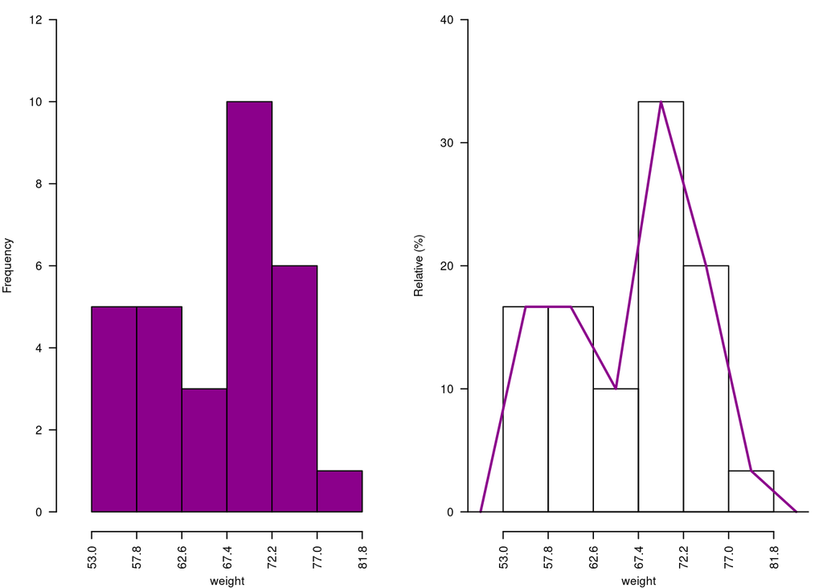

Figure 1.1: Absolute and relative frequency with polygon

```r
oldpar<-par(mfrow=c(1,2),mar=c(4,4,0,1),cex=0.6)
h1<- graph.freq(weight,col=colors()[84],frequency=1,las=2, ylim=c(0,12),ylab="Frequency")
x<-h1$breaks
h2<- plot(h1, frequency =2, axes= FALSE,ylim=c(0,0.4),xlab="weight",ylab="Relative (%)")
polygon.freq(h2, col=colors()[84], lwd=2, frequency =2)
axis(1,x,cex=0.6,las=2)
y<-seq(0,0.4,0.1)
axis(2, y,y*100,cex=0.6,las=1)
```

```r
par(oldpar)
```

## 1.2 Statistics and Frequency tables

Statistics: mean, median, mode and standard deviation of the grouped data.

```r
stat.freq(h1)
```

```
$variance
[1] 51.37655

$mean
[1] 66.6

$median
[1] 68.36

$mode
       [-   -]     mode
[1,] 67.4 72.2 70.45455
```

Frequency tables: Use *table.freq*, *stat.freq* and *summary*

The table.freq is equal to summary()

Limits class: **Lower and Upper**

Class point: **Main**

Frequency: **Frequency**

Percentage frequency: **Percentage**

Cumulative frequency: **CF**

Cumulative percentage frequency: **CPF**

```r
print(summary(h1),row.names=FALSE)
```

```
 Lower Upper Main Frequency Percentage CF   CPF
  53.0  57.8 55.4         5       16.7  5  16.7
  57.8  62.6 60.2         5       16.7 10  33.3
  62.6  67.4 65.0         3       10.0 13  43.3
  67.4  72.2 69.8        10       33.3 23  76.7
  72.2  77.0 74.6         6       20.0 29  96.7
  77.0  81.8 79.4         1        3.3 30 100.0
```

## 1.3 Histogram manipulation functions

You can extract information from a histogram such as class intervals *intervals.freq*, attract new intervals with the *sturges.freq* function or to join classes with *join.freq* function. It is also possible to reproduce the graph with the same creator *graph.freq* or function *plot* and overlay normal function with *normal.freq* be it a histogram in absolute scale, relative or density . The following examples illustrates these properties.

```r
sturges.freq(weight)
```

```
$maximum
[1] 81.5

$minimum
[1] 53

$amplitude
[1] 29

$classes
[1] 6

$interval
[1] 4.8

$breaks
[1] 53.0 57.8 62.6 67.4 72.2 77.0 81.8
```

```r
intervals.freq(h1)
```

```
     lower upper
[1,]  53.0  57.8
[2,]  57.8  62.6
[3,]  62.6  67.4
[4,]  67.4  72.2
[5,]  72.2  77.0
[6,]  77.0  81.8
```

```r
join.freq(h1,1:3) -> h3
print(summary(h3))
```

```
  Lower Upper Main Frequency Percentage CF   CPF
1  53.0  67.4 60.2        13       43.3 13  43.3
2  67.4  72.2 69.8        10       33.3 23  76.7
3  72.2  77.0 74.6         6       20.0 29  96.7
4  77.0  81.8 79.4         1        3.3 30 100.0
```

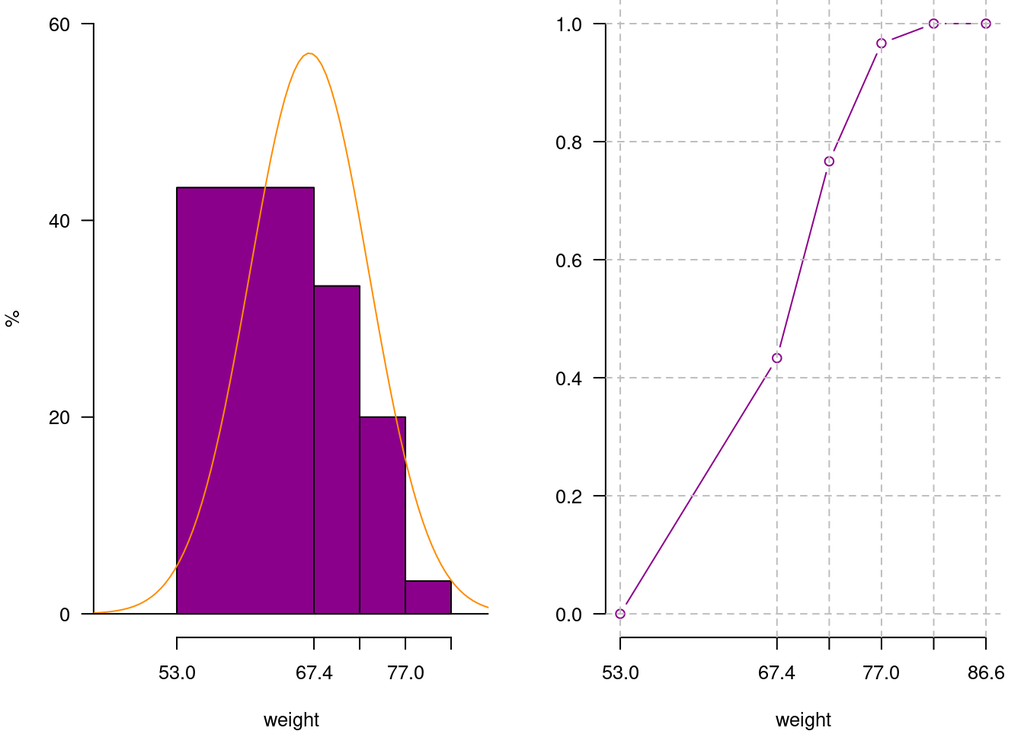

Figure 1.2: Join frequency and relative frequency with normal and Ogive

```
  weight    RCF
1   53.0 0.0000
2   67.4 0.4333
3   72.2 0.7667
4   77.0 0.9667
5   81.8 1.0000
6   86.6 1.0000
```

```r
oldpar<-par(mfrow=c(1,2),mar=c(4,4,0,1),cex=0.8)
plot(h3, frequency=2,col=colors()[84],ylim=c(0,0.6),axes=FALSE,xlab="weight",ylab="%")
y<-seq(0,0.6,0.2)
axis(2,y,y*100,las=2)
axis(1,h3$breaks)
normal.freq(h3,frequency=2,col=colors()[90])
ogive.freq(h3,col=colors()[84],xlab="weight")
```

```r
par(oldpar)
```

## 1.4 hist() and graph.freq() based on grouped data

The *hist* and *graph.freq* have the same characteristics, only f2 allows build histogram from grouped data.

0-10 (3)

10-20 (8)

20-30 (15)

30-40 (18)

40-50 (6)

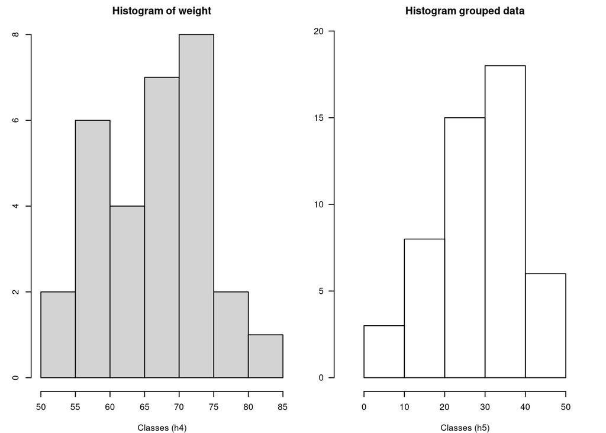

Figure 1.3: hist() function and histogram defined class

```r
oldpar<-par(mfrow=c(1,2),mar=c(4,3,2,1),cex=0.6)
h4<-hist(weight,xlab="Classes (h4)")
table.freq(h4)
# this is possible
# hh<-graph.freq(h4,plot=FALSE)
# summary(hh)
# new class
classes <- c(0, 10, 20, 30, 40, 50)
freq <- c(3, 8, 15, 18, 6)
h5 <- graph.freq(classes,counts=freq, xlab="Classes (h5)",main="Histogram grouped data")
```

```r
par(oldpar)
```

```r
print(summary(h5),row.names=FALSE)
```

```
 Lower Upper Main Frequency Percentage CF CPF
     0    10    5         3          6  3   6
    10    20   15         8         16 11  22
    20    30   25        15         30 26  52
    30    40   35        18         36 44  88
    40    50   45         6         12 50 100
```